# How do IUCN Range maps of birds compare to SDMs in Indonesian New Guinea? What are the main predictors for this distribution?

Jonathan Gehret, Paul Leister

31.08.2021

# 1. Introduction

# 2. Methods

For the creation of this HTML document, the MCMMB.Rmd was knitted. To find the species to be used for our analysis we used the loops in bird_plot_loops.R to plot all species from the Gbif and IUCN data sets to find birds with sufficient observation points and different ranges to be used for our project.

## 2.1. Main script

The required libraries and the setup of the IUCN and gbif data sets are done in the MCMMB_Main.R script. Notably, the HBIF data are created only for species with greater than 100 observations.The GBIF data were downloaded manually beforehand, however the r library “rgbif” could be used instead. Additionally, the island borders are read in and given the name “regio”.

```r
source("MCMMB_Main.R")
```

## 2.2. Species data

The script species_loops.R includes two functions each for creating lists with the input bird species data for gbif (“get_gbif_birds(bird_names,gbif_crop,regio)”) and IUCN (“get_iucn_birds(bird_names,birdlife,regio)”) and plotting them, respectively.

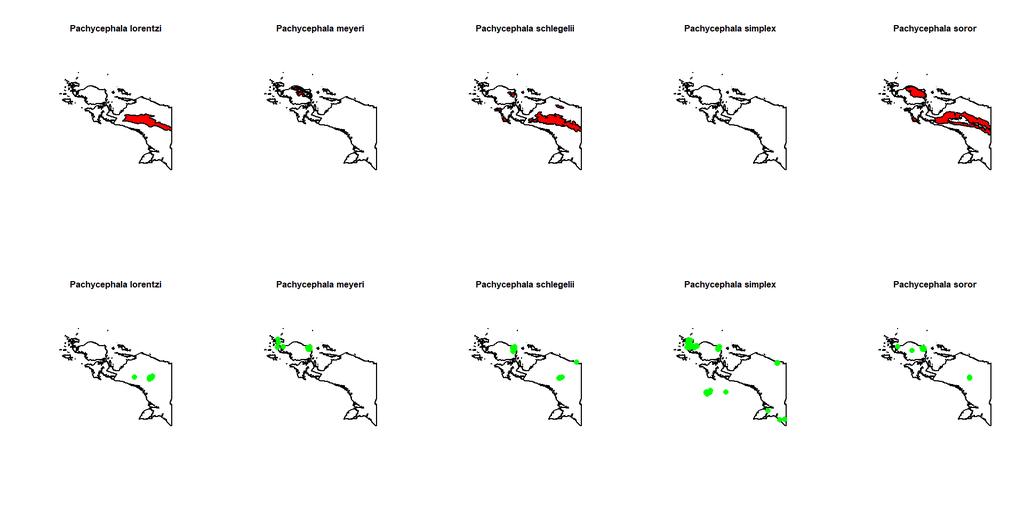

```r
# loading of the described functions
source("species_loops.R")

# cassowaries didn't have enough data
#bird_names = c("Casuarius bennetti", "Casuarius casuarius", "Casuarius unappendiculatus")

# we chose Pachycephala instead
bird_names = c("Pachycephala lorentzi",
               "Pachycephala meyeri",
               "Pachycephala schlegelii",
               "Pachycephala simplex",
               "Pachycephala soror")

# these names can be changed to any other bird species occuring in the data sets, for fully automated creation of sdms following this markdown file:
# bird_names = c(your_favorite_species_here)

# for plotting gbif data next to iucn data
par(mfrow = c(2,length(bird_names)))

# create list with birds out of the iucn and gbif data and plot them
# IUCN birdlife data is shown in red
# GBIF points are shown in green
iucn_birds = get_iucn_birds(bird_names,birdlife,regio)
gbif_birds = get_gbif_birds(bird_names,gbif_crop,regio)
```

## 2.3. Create presence-absence data

While biomod2 also brings with it capabilities to create pseudo-absence data, we built a script to do it. First centroids for the area were created, based on that an equal number to the presence data of absence points is created.

```
"Be sure to take care when considering the use of pseudo-absences versus true absences for species distribution
modeling. Similarly, it is extremely important to consider the influence of sampling bias in the data used to
train models. Further reading: e.g., Guillera-Arroita et al. 2015, Kramer-Schadt et al. 2013, and Merow et al
2013."
```

```r
# load presence_absence.R script including the function
source("presence_absence.R")
par(mfrow = c(3,3))
presence_absence_list = create_pseudo_absence(regio,gbif_birds)
```

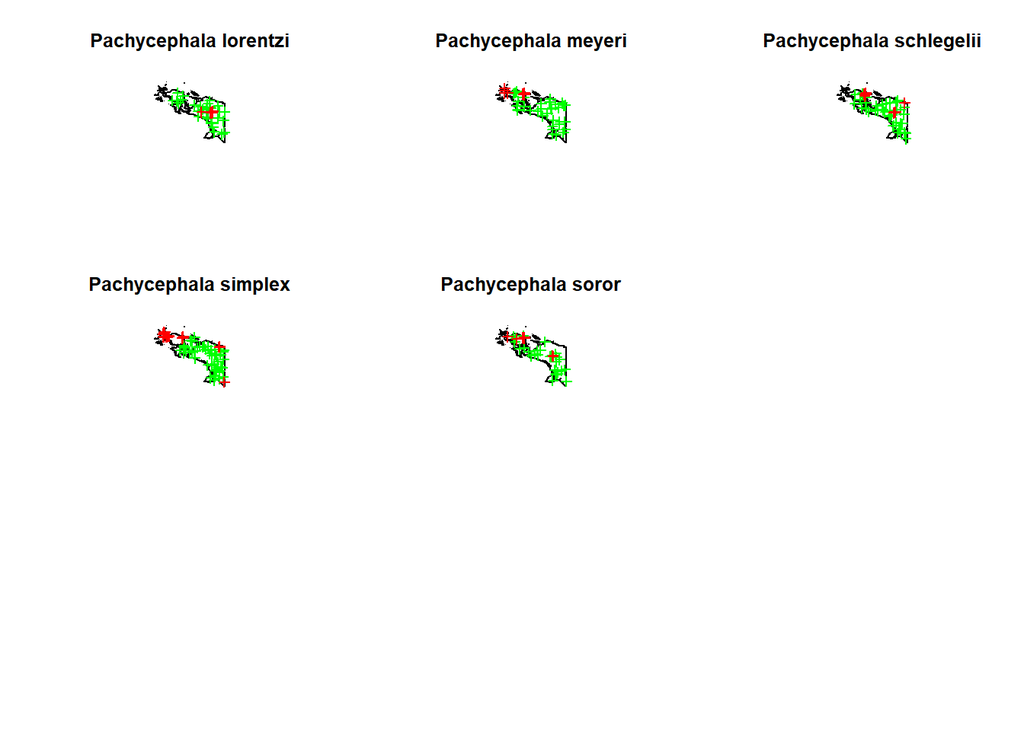